# STA 141A Fall 2022: Homework 2

Camden Possinger

10/21/22

# 1. Examining the distribution of the data

1. Read the data into R. Add to the data frame a new binary variable good which is 1 if quality > 5 and 0 otherwise (1 point).

```r
library(readr)
library(dplyr)
library(purrr)
library(ggplot2)
```

```r
preprocess <- function(file) {
  read_delim(file, ";", show_col_types = FALSE) %>%
    select(pH, quality) %>%
    mutate(good = ifelse(quality > 5, "1", "0")) %>%
    select(-quality)
}

preprocess("winequality-white.csv")
```

```
## # A tibble: 4,898 × 2
##       pH good
##    <dbl> <chr>
##  1  3    1
##  2  3.3  1
##  3  3.26 1
##  4  3.19 1
##  5  3.19 1
##  6  3.26 1
##  7  3.18 1
##  8  3    1
##  9  3.3  1
## 10  3.22 1
## # … with 4,888 more rows
```

2. Calculate the summary statistics for `pH` for good, bad and all wines separately, that is: mean, median, standard deviation, interquartile range, minimum and maximum of both samples. Display the results in a table and comment on the differences between both groups, if any (1 point).

```r
nest_df <- function(df) {
  tibble(
    good = c("0", "1", "all"),
    data = list(
      df %>% filter(good == "0") %>% select(pH),
      df %>% filter(good == "1") %>% select(pH),
      df %>% select(pH)
    )
  )
}

summary_tbl <- function(df) {
  df %>%
    mutate(summary = map(data, ~ .x$pH %>%
      summary() %>%
      append(c(SD = sd(.x$pH))))) %>%
    select(good, summary) %>%
    tidyr::unnest_wider(summary)
}

preprocess("winequality-white.csv") %>%
  nest_df() %>%
  summary_tbl()
```

```
## # A tibble: 3 × 8
##   good   Min. `1st Qu.` Median  Mean `3rd Qu.`  Max.    SD
##   <chr> <dbl>     <dbl>  <dbl> <dbl>     <dbl> <dbl> <dbl>
## 1 0      2.79      3.08   3.16  3.17      3.24  3.79 0.144
## 2 1      2.72      3.09   3.19  3.20      3.3   3.82 0.154
## 3 all    2.72      3.09   3.18  3.19      3.28  3.82 0.151
```

- Based on the results of the table there isn’t much of a difference between the pH of the wines that are good or bad. Everything is pretty similar across the board.
3. Plot a histogram of `pH` for good, bad and all wines and add to the plots a normal density, estimating the parameters from the data. Produce same histograms with corresponding normal densities for good and bad wines separately. Do you observe any differences in the distributions? (2 point).

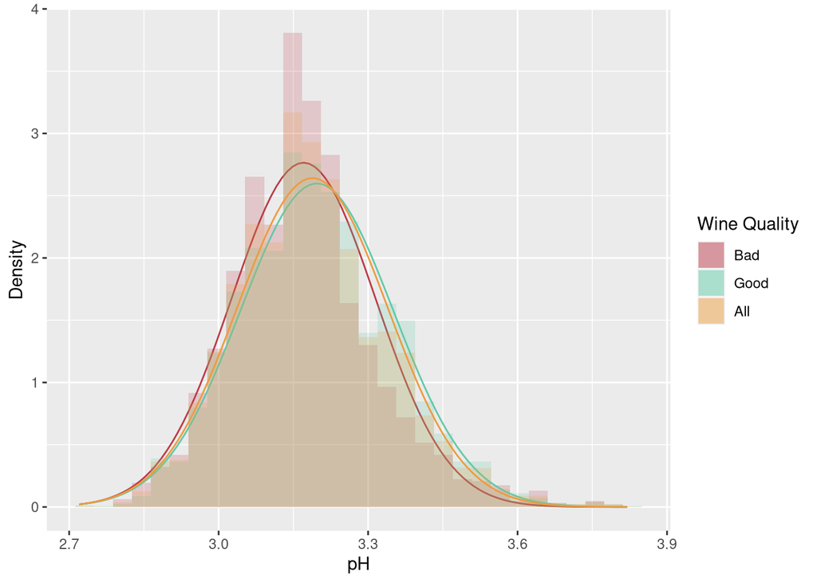

```r
create_hists <- function(df) {
  color <- c("Bad" = "#ba3b46", "Good" = "#61c9a8", "All" = "#ed9b40")

  df %>%
    mutate(
      hist = imap(data, ~ ggplot() +
        geom_histogram(
          data = .x,
          aes(x = pH, fill = names(color)[.y], y = ..density..),
          alpha = 0.2,
          bins = 30
        ) +
        geom_function(
          fun = dnorm,
          args = list(
            mean = df[[.y, "data"]][[1]]$pH %>% mean(),
            sd = df[[.y, "data"]][[1]]$pH %>% sd()
          ),
          color = color[.y]
        ) +
        scale_fill_manual(
          name = "Wine Quality",
          values = color[.y]
        ) +
        ylab("Density"))
    )
}


combined_hist <- function(df) {
  color <- c("Bad" = "#ba3b46", "Good" = "#61c9a8", "All" = "#ed9b40")

  plot <- ggplot()
  plot$layers <- df$hist %>%
    map(~ .x$layers) %>%
    unlist()

  plot + ylab("Density") + xlab("pH") + scale_fill_manual(
    name = "Wine Quality",
    values = color
  )
}

preprocess("winequality-white.csv") %>%
  nest_df() %>%
  create_hists() %>%
  combined_hist()
```

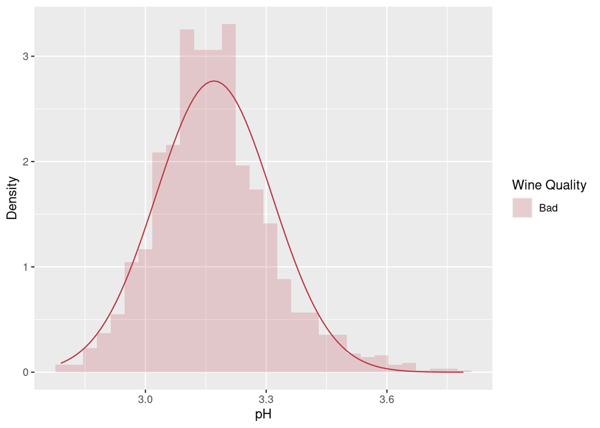

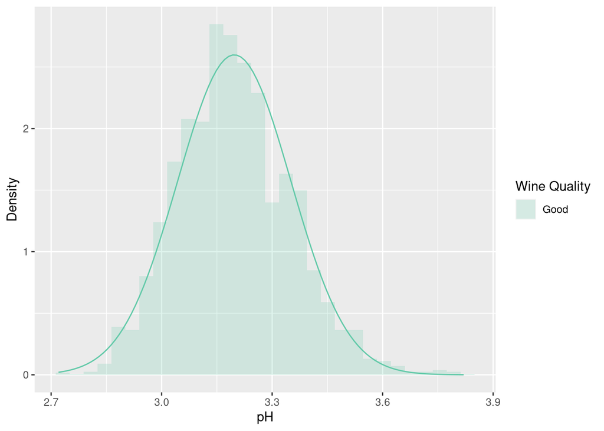

```r
preprocess("winequality-white.csv") %>%
  nest_df() %>%
  create_hists() %>%
  filter(good == "1" | good == "0") %>%
  pull(hist)
```

- Based on the plot above the corresponding histograms for good, bad, and all wine qualities show that the pH is similarly distributed.
- All of these curves follow a normal distribution.
- We can see that the mean pH of bad quality wine is a bit smaller than the pH of good and all quality wine.
- We can also see that the distribution of bad wine quality is narrower than the distribution of good and all wine quality which  
  indicates that there is less variance associated with pH.
- It is much easier to compare these plots when they are combined into one plot. When the plots are seperated  
  we could probably make out that the bad quality pH mean is smaller but probably wouldn’t pick up on the difference in variance.
4. Generate QQ-plots with `ggplot` of `pH` for good, bad and all wines to compare empirical quantiles of the samples to the theoretical quantiles of a normal distribution. Add a angle bisector line to the plot. Do you think all samples follow a normal distribution? (1 points).

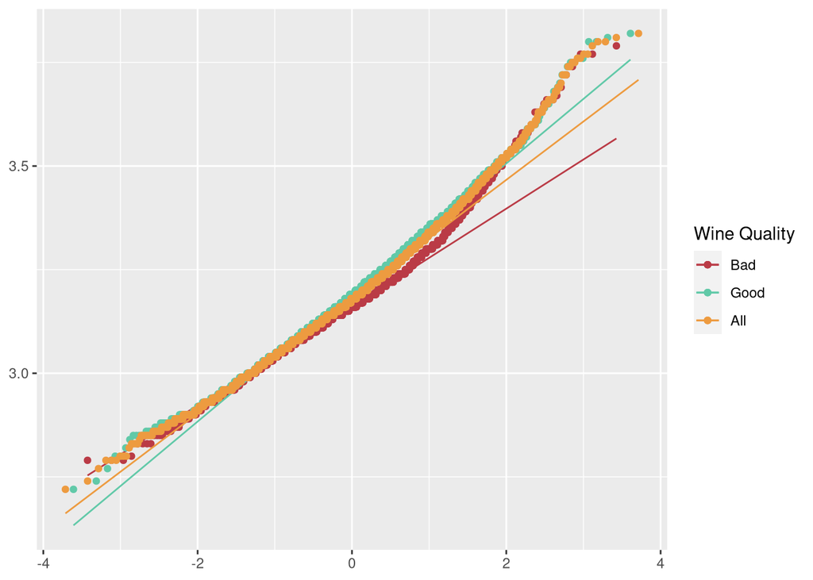

```r
create_qq_plots <- function(df) {
  color <- c("Bad" = "#ba3b46", "Good" = "#61c9a8", "All" = "#ed9b40")

  df %>%
    mutate(
      qq_plot = imap(data, ~ ggplot() +
        geom_qq(data = .x, aes(
          sample = pH,
          color = names(color)[.y]
        )) +
        geom_qq_line(
          data = .x,
          aes(
            sample = pH,
            color = names(color)[.y]
          )
        ))
    )
}


combined_qq_plot <- function(df) {
  color <- c("Bad" = "#ba3b46", "Good" = "#61c9a8", "All" = "#ed9b40")

  plot <- ggplot()
  plot$layers <- df$qq_plot %>%
    map(~ .x$layers) %>%
    unlist()

  plot + scale_color_manual(
    name = "Wine Quality",
    values = color
  )
}


preprocess("winequality-white.csv") %>%
  nest_df() %>%
  create_qq_plots() %>%
  combined_qq_plot()
```

- It seems that the distribution of pH for good quality wine  
  follows a normal distribution.
- It seems that the distribution of pH for bad quality wine  
  does not follow a normal distribution it is right skewed  
  with a heavy right tail.
- It seems that the distribution of pH for all quality wine  
  follows a normal distribution but it has a heavier right  
  tail than the distribution for the pH of good quality wine.

# 2. Simulation study

Suppose that $X_1,\ldots,X_n$ are independent and identically distributed (iid) binomial random variables such that
$$P(X_i=x\mid k,p)
={k\choose x}p^x(1-p)^{k-x},\quad x=0,1,\ldots,k$$
for all $i=1,\ldots,n$. Assume that both $k$ and $p$ are unknown and use the method of moments to obtain point estimators of both parameters. This somewhat unusual application of the binomial model has been used to estimate crime rates for crimes that are known to have many unreported occurrences. For such a crime, both the true reporting rate, $p$, and the total number of occurrences, $k$, are unknown. Equating the first two sample moments to those of the population yields the system of equations
$$\bar X=kp
\quad\text{and}\quad
\frac1n\sum_{i=1}^nX_i^2=kp(1-p)+k^2p^2,$$
where $\bar X$ is the sample mean. Solving for $k$ and $p$ leads to
$$\hat k=\frac{\bar X^2}{\bar X-(1/n)\sum_{i=1}^n(X_i-\bar X)^2}
\quad\text{and}\quad
\hat p=\frac{\bar X}{\hat k}.$$
It is difficult to analyze the performance of $\hat k$ and $\hat p$ analytically so you are asked to perform a simulation study using `R`. The idea is to generate random samples and investigate the performance of $\hat k$ and $\hat p$ using random samples.

1. Generate a single simple random sample of length `n <- 50` from the binomial distribution with the parameters `k <- 10`, `p <- 0.4` (1 point).

```r
rbinom(50, 10, 0.4)
```

```
##  [1] 4 2 2 6 4 3 2 6 3 4 2 4 6 2 5 2 4 4 3 5 3 4 3 7 6 5 4 6 4 5 4 3 2 5
## [35] 3 8 3 3 2 6 6 3 5 3 6 1 4 3 5 5
```

2. Write a function that takes a sample as its input and returns a vector containing the estimates of `k` and `p` given above (3 points).

```r
set.seed(101)

estimate_parameters <- function(sample) {
  x_bar <- mean(sample)
  n <- length(sample)
  k_hat <- x_bar^2 / (x_bar - (1 / n * sum((sample - x_bar)^2)))
  p_hat <- x_bar / k_hat
  c("k_hat" = k_hat, "p_hat" = p_hat)
}

estimate_parameters(rbinom(50, 10, 0.4))
```

```
##     k_hat     p_hat
## 7.9186163 0.5026131
```

3. Generate `N <- 1000` samples of size `n <- 50` (as in the first question) and calculate `N <- 1000` estimates of $k$ and `N <- 1000` estimates of $p$ (4 points if no loops are used in the code, 2 points if any loop (`for`, `while`, `repeat`, etc.) is used in the code ).

```r
est_param_df <- function(n) {
  set.seed(101)
  1:1000 %>%
    map(~ rbinom(n, 10, 0.4)) %>%
    map_df(~ estimate_parameters(.x))
}


est_param_df(50)
```

```
## # A tibble: 1,000 × 2
##    k_hat p_hat
##    <dbl> <dbl>
##  1  7.92 0.503
##  2 11.8  0.365
##  3 13.1  0.303
##  4 14.8  0.294
##  5  7.74 0.496
##  6 10.5  0.38
##  7  9.07 0.423
##  8 10.4  0.393
##  9  8.41 0.54
## 10  6.61 0.569
## # … with 990 more rows
```

4. Repeat Question 3 when `n <- 100` and when `n <- 250` (2 points).

```r
est_param_df(100)
```

```
## # A tibble: 1,000 × 2
##    k_hat p_hat
##    <dbl> <dbl>
##  1  9.74 0.425
##  2 14.3  0.290
##  3  9.01 0.435
##  4  9.85 0.403
##  5  8.04 0.516
##  6  7.98 0.491
##  7 11.8  0.338
##  8 12.9  0.304
##  9 10.7  0.356
## 10 11.8  0.323
## # … with 990 more rows
```

```r
est_param_df(250)
```

```
## # A tibble: 1,000 × 2
##    k_hat p_hat
##    <dbl> <dbl>
##  1 10.8  0.380
##  2  9.13 0.443
##  3 10.3  0.383
##  4 11.2  0.341
##  5  9.37 0.436
##  6  8.13 0.492
##  7  9.86 0.415
##  8 13.5  0.313
##  9 10.5  0.378
## 10 10.1  0.375
## # … with 990 more rows
```

5. Estimate the bias and the mean squared error (MSE),
   $$MSE(k,\hat k) = \sum_{i=1}^n(k - \hat k)^2,$$
   of $\hat k$ and the bias and the MSE of $\hat p$ for each sample size (`n <- 50`, `n <- 100` and `n <- 250`). Do the estimators seem to overestimate or underestimate the parameters? How do the bias and the MSE change when the sample size increases? (3 points).

```r
mse <- function(est_param, true_param, n) {
  sum((true_param - est_param)^2) / n
}

bias <- function(est_param, true_param) {
  mean(est_param) - true_param
}


disp_df <- function(param, true_value) {
  c(50, 100, 250) %>%
    set_names() %>%
    map_dfr(function(n) {
      df <- est_param_df(n)
      list(
        "MSE" = df %>% pull({{ param }}) %>% mse(true_value, n),
        "Bias" = df %>% pull({{ param }}) %>% bias(true_value)
      )
    }, .id = "n")
}



disp_df(k_hat, 10)
```

```
## # A tibble: 3 × 3
##   n        MSE   Bias
##   <chr>  <dbl>  <dbl>
## 1 50    771.   0.925
## 2 100    55.2  0.168
## 3 250     7.65 0.0179
```

```r
disp_df(p_hat, 0.4)
```

```
## # A tibble: 3 × 3
##   n        MSE    Bias
##   <chr>  <dbl>   <dbl>
## 1 50    0.279  0.0142
## 2 100   0.0655 0.0105
## 3 250   0.0114 0.00651
```

- Both estimators overestimate the parameters because the bias is positive
- Both the bias and MSE decrease when the sample size increases
1. Make a single plot using `ggplot2` that contains three box plots of the estimates of the parameter `k` when `n <- 50`, `n <- 100`, `n <- 250` (the first from the left box plot has to describe the estimates when `n <- 50`, the second from the left box plot has to describe the estimates when `n <- 100` and the third from the left box plot has to describe the estimates `n <- 250`). Include the true value of the parameter as a horizontal line (`geom_hline()` and use the argument `color`) and label the plot appropriately (4 points).

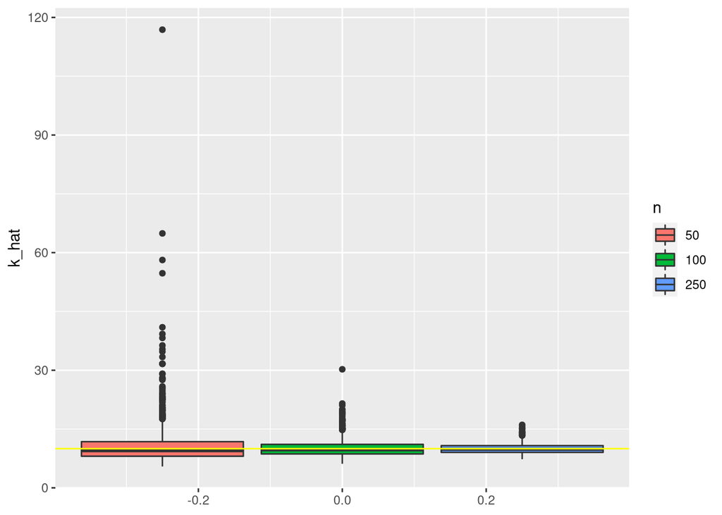

```r
param_df <- function() {
  c(50, 100, 250) %>%
    set_names() %>%
    map_dfr(~ est_param_df(.x), .id = "n")
}

param_boxplot <- function(df, param, true_value) {
  plot <- ggplot(
    data = df,
    aes(
      y = {{ param }},
      fill = factor(as.integer(n))
    )
  ) +
    geom_boxplot() +
    geom_hline(yintercept = true_value, color = "yellow") +
    guides(fill = guide_legend(title = "n"))


  plot
}

param_df() %>% param_boxplot(k_hat, 10)
```

2. $\hat k$ can obtain values that are far away from the true value of the parameter when the sample size is small and the box plots might not be particularly informative in such a situation. Remove the estimates from the plot that are outside of the interval $[0,50]$ so that the box plots are more informative (4 points).

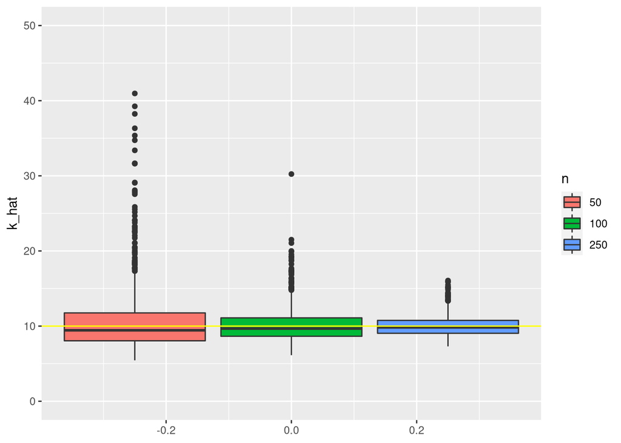

```r
param_boxplot <- function(df, param, true_value) {
  plot <- ggplot(
    data = df,
    aes(
      y = {{ param }},
      fill = factor(as.integer(n))
    )
  ) +
    geom_boxplot() +
    geom_hline(yintercept = true_value, color = "yellow") +
    guides(fill = guide_legend(title = "n"))

  if (rlang::as_name(enquo(param)) == "k_hat") plot <- plot + ylim(0, 50)


  plot
}

param_df() %>% param_boxplot(k_hat, 10)
```

3. Make the same plot with three box plots for the estimates of the parameter `p` (b part does not apply here) (2 points).

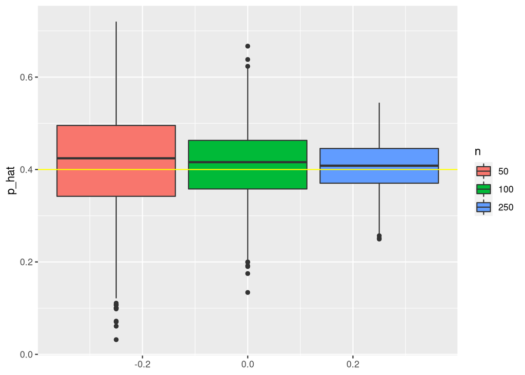

```r
param_df() %>% param_boxplot(p_hat, 0.4)
```

4. Describe how both of these plots change when the sample size increases (2 points).
- We can see in both plots that the variance of the estimates becomes smaller with increasing sample size.
- Each box plot gets shorter towards the true value of the parameter from left to right.
- In both plots the outlier points become become more centralized  
  around the true value of the parameter.